# Computational Musicology

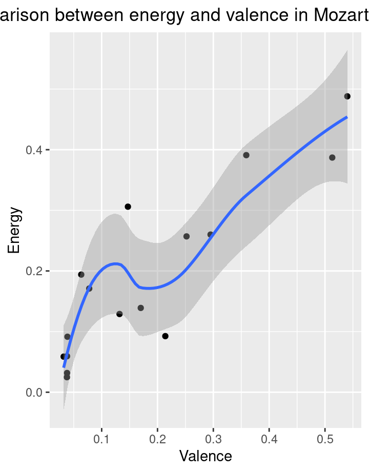

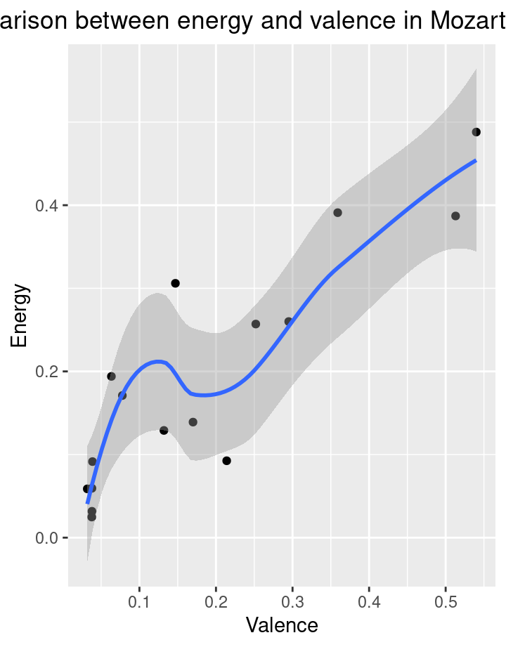

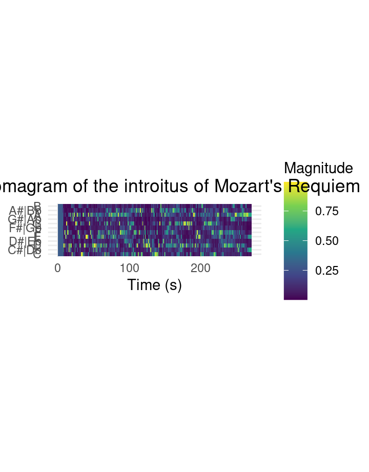

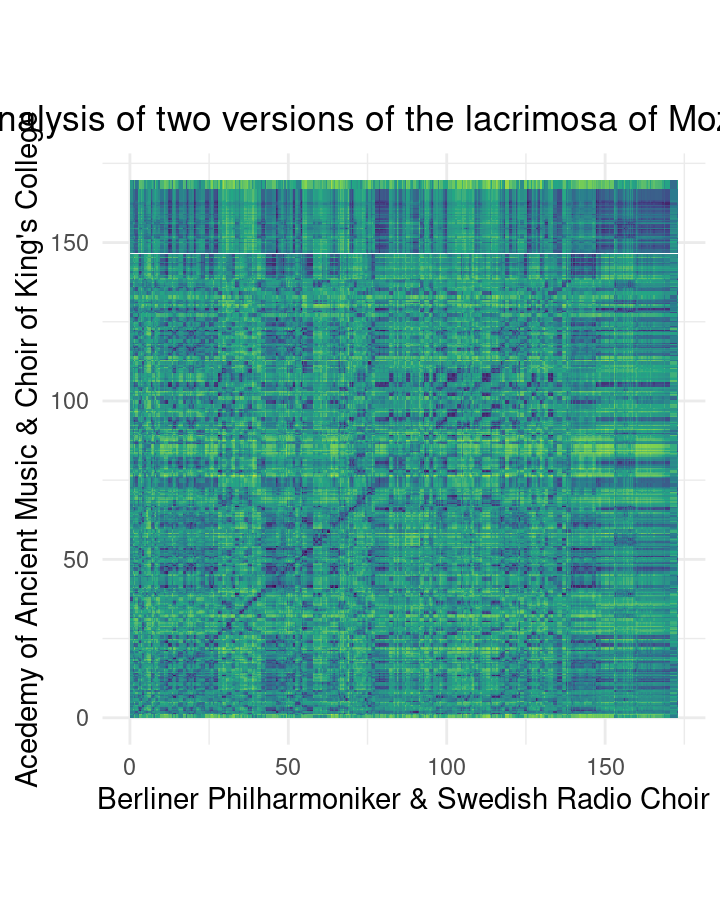

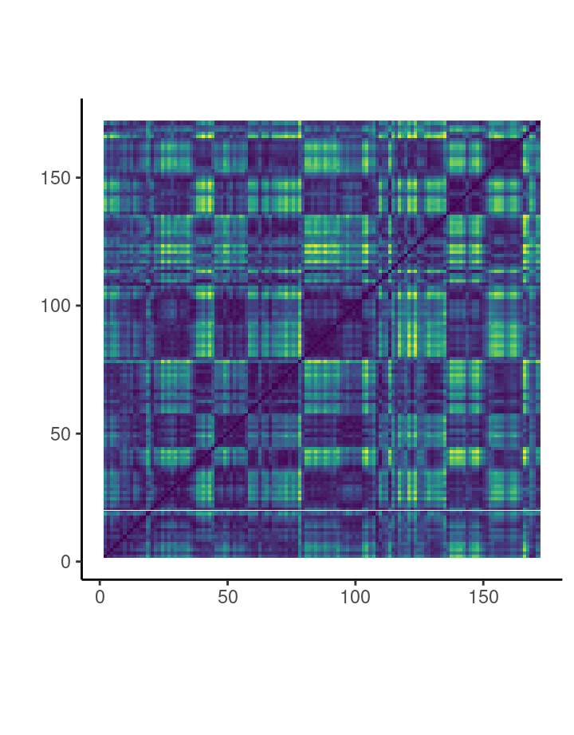

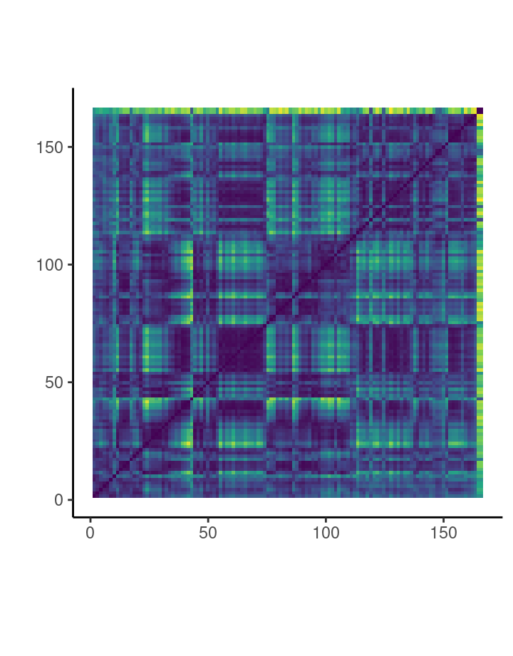

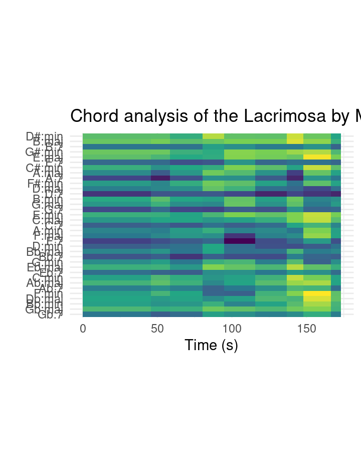

# Tempogram

### Tempogram Lacrimosa Mozart

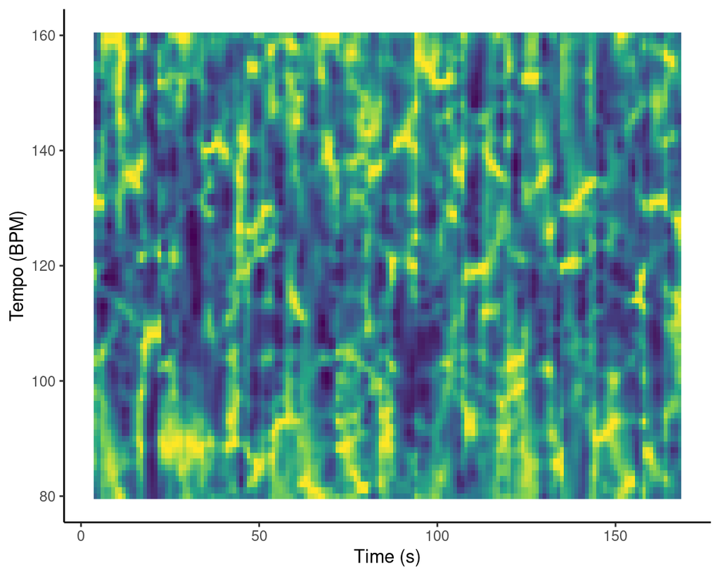

### Description

As you can see in the tempogram on the right the attempt to recognize any constant tempo for this recording of the Lacrimosa by Mozart performed by the Berliner Philharmoniker was not really successful. There are multiple reasons why this is the case. First of all there is no clear percussion in this piece that plays throughout. The second thing that most likely contributes to the lack of recognizably for any tempo is the fact that the piece consist of mostly strings and vocals. These instruments have a relatively slow attack and thus no clear onsets which the tempo analysis function can grab onto. There is however a higher likelihood of the tempo being around 87 BPM, especially between 20 and 50 seconds. This piece should be performed around 84 BPM, so this is the closest the algorithm came to a correct estimation of the tempo of this recording.

# Overview

### Overview

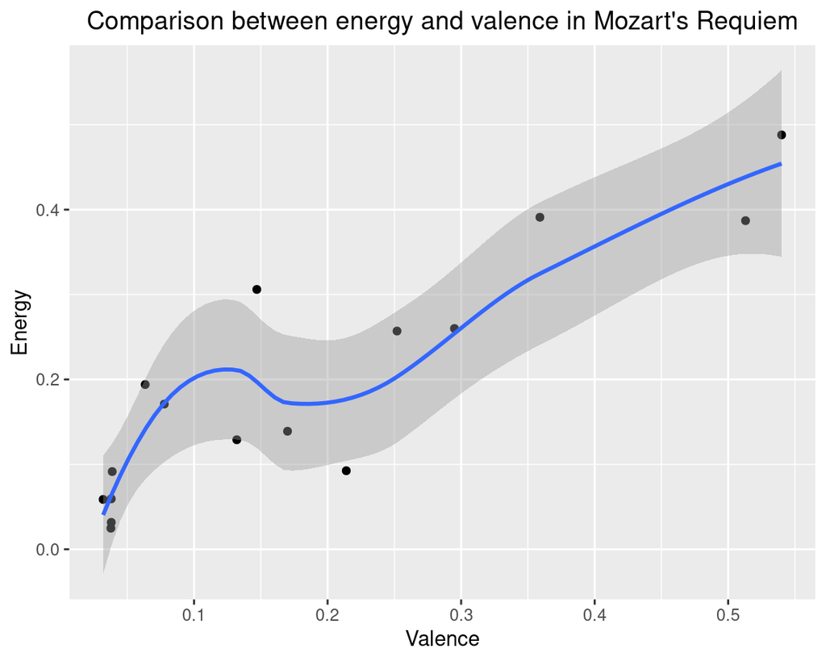

### Corpus description

My corpus is a collection of multiple versions of the most common parts of a requiem mass, each by a different composer. While the texts of a requiem mass is (almost always) the same the music that composers have made based on these texts differs a lot. I was inspired to choose this as my corpus because I have sung the choir part of multiple requiem masses in the past and currently the choir I sing in is rehearsing the requiem by Mozart, which we will perform in april. Some other examples of composers that have written a requiem mass are Britten, Fauré and Duruflé, but many more versions by other composers are required to make any meaningful comparisons.

The things that are most interesting to look at are the difference in energy, valence and tempo of each requiem. This difference can be analyzed between the same part of the mass but from different composers or the difference between all the parts from the same mass by a single composer. Certain parts of requiem masses are very well known like the Dies Irae by Mozart. Which version by another composer has the most in common with a well known version of the same part and do they even sound somewhat similar at all? Is there a difference in how the texts of requiem have been put to music throughout time? These are things to look at with this collection of music.

A limitation of this corpus could be that the different versions by different composers have quite similar characteristics and can not produce any meaningful insight.

# Mozart

### Mozart

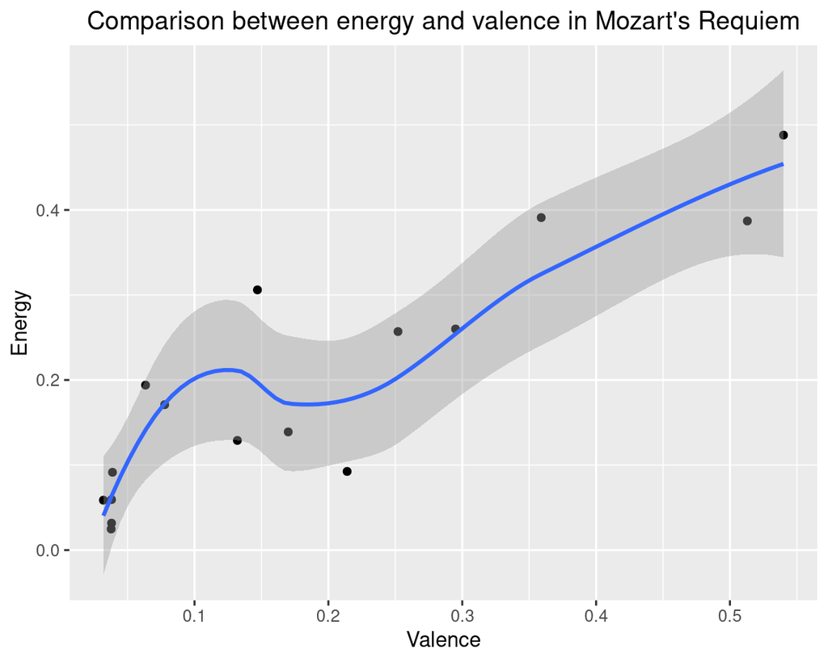

### Description

This image shows there is some correlation between the energy level and valence of different parts of the requiem by Mozart. This could be because the more serious or sadder parts of the requiem are slower on average and thus Spotify classifies them as less energetic. Another cause could be that Spotify can’t really distinguish the difference between serious and a higher tempo and thus classifies parts with a higher tempo as having a higher valence and energy.

# Chromagram

### Chromagram

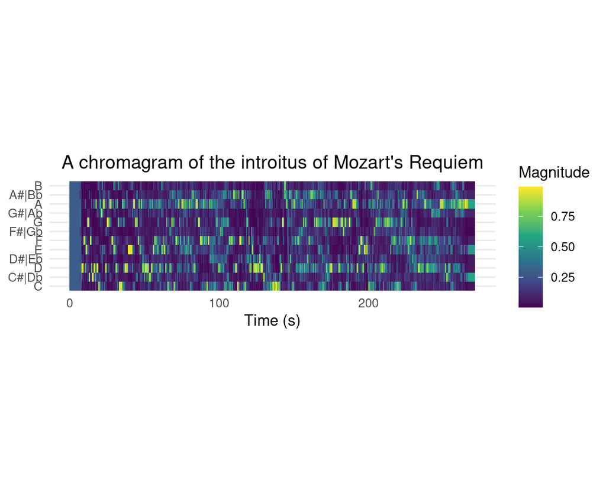

### Chromagram of the introitus of Mozart’s Requiem

# Dynamic Time Warping

### Dynamic Time Warping

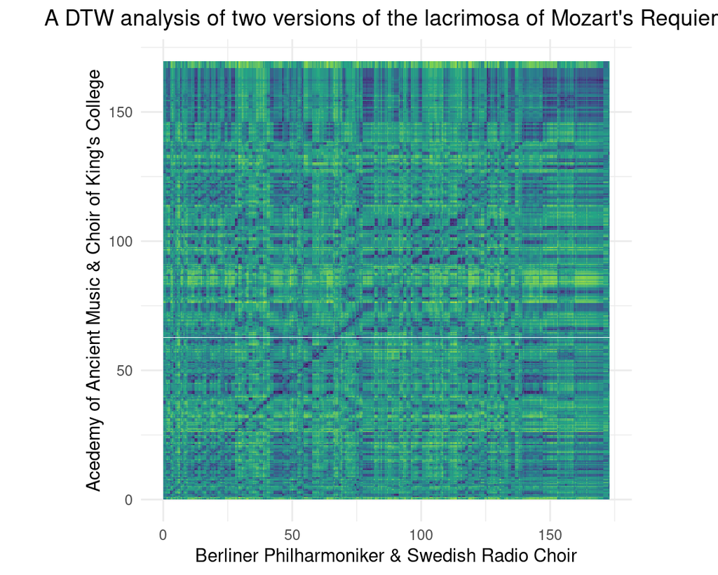

### Dynamic Time Warping of two different versions of the lacrimosa of the Requiem by Mozart

# SSM Lacrimosa

### Berliner Philharmoniker & Swedish Radio Choir

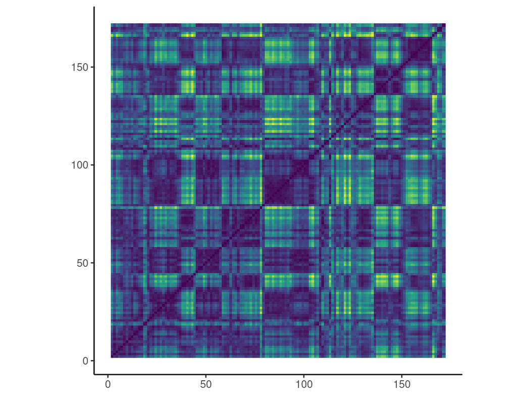

### Acedemy of Ancient Music & Choir of King’s College

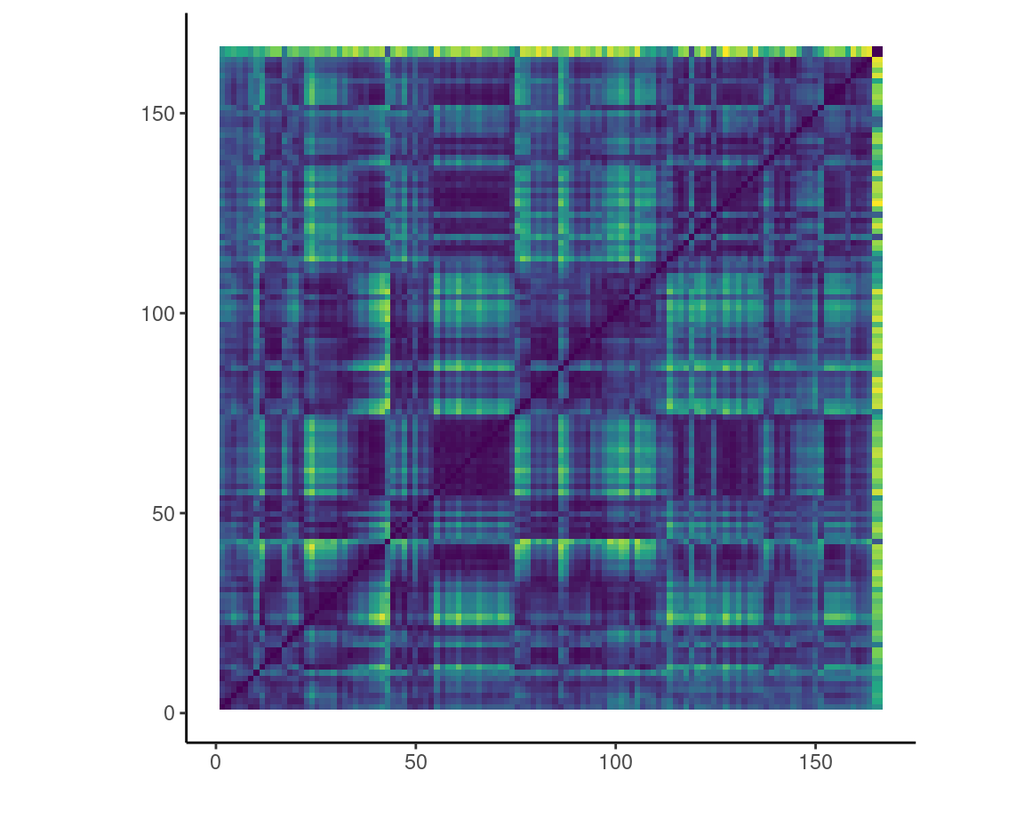

### Description

On this page two self-similarity matrices are shown. These are from two different recordings of the Lacrimosa from the Reqiuem by Mozart. The first one is by the Berliner Philharmoniker and the Swedish Radio Choir, the second one is by the Acedemy of Ancient Music and the Choir of King’s College. The sections that are visible in both of the matrices do somewhat line up, but certain sections seem longer in the second matrix.

# Chord analysis

### Chord analysis

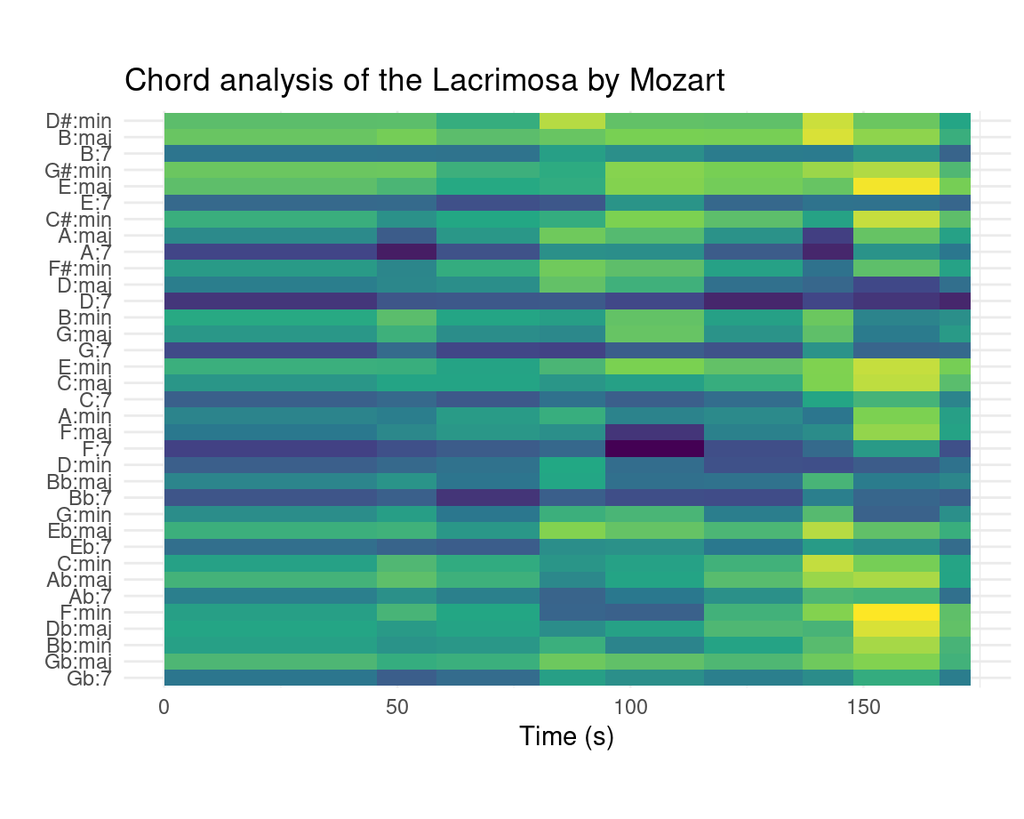

### Description

In this chordogram it is visible that mainly D, F and A chords are present in this piece. This matches up since it is written in D minor, but changes a lot with many accidentals. The start of the piece should contain a lot more of the actual D minor chord, but that is not visible in this chordogram. This could be because the instruments were tuned lower than `A = 440 Hz` which is quite common for orchestras playing pieces from the classical period to do. From this chord analysis it also quite visible that from around 95 to 110 seconds there is very high match for a F chord. This matches up with the part of the piece that only the orchestra is playing a lot of notes that are part of a F major chord.